# Section A: Student-level Changes during COVID-19

# A.3. Course Taking

> A.3.1. Statewide breakdown by groups

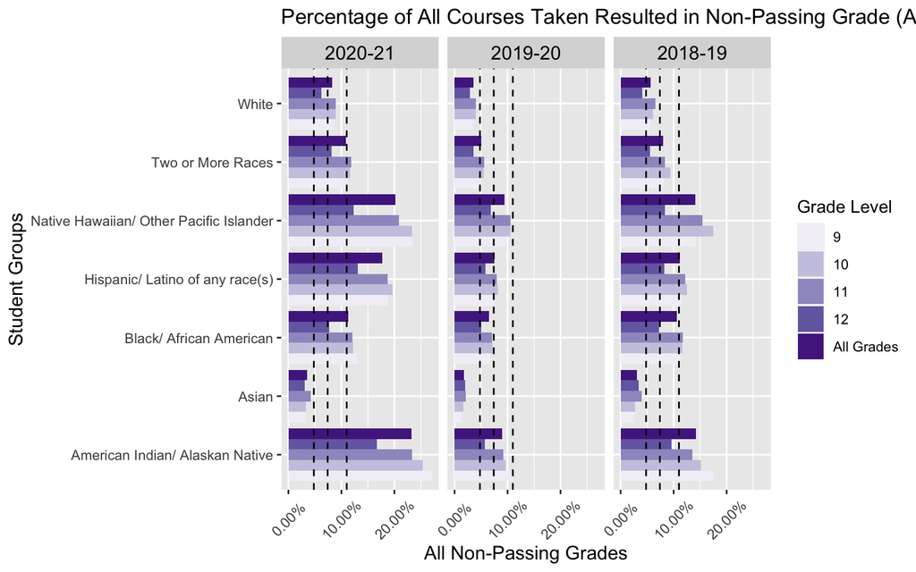

> A.3.2.1 Geographical differences across districts in all non-passing grade from 2018-19 to 2020-21

students of color (excluding Asian)

For spatial plots: missing data (grey areas) results from

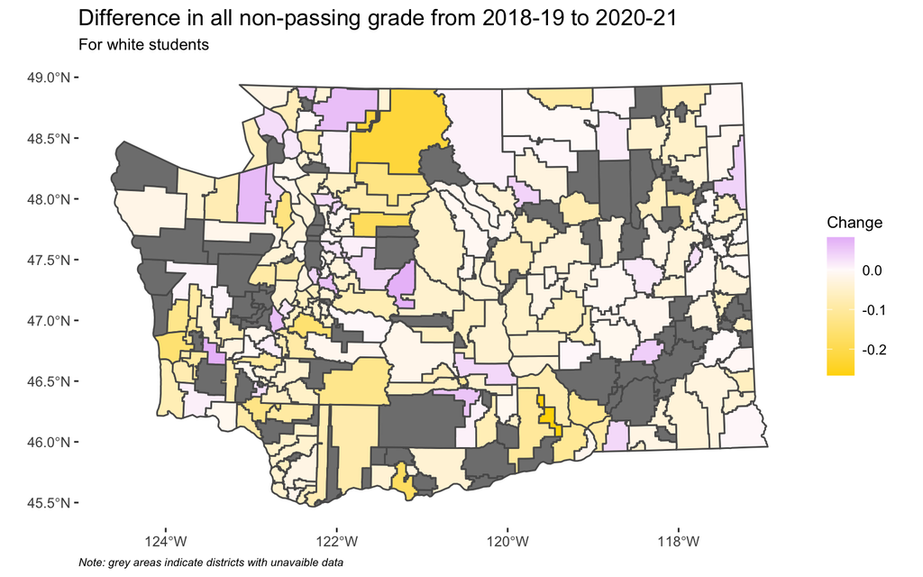

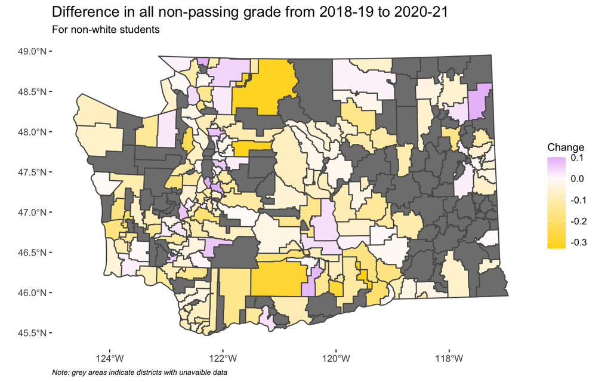

> A.3.2.2 The gap in all non-passing in 2020-21 between students of color and white for each district

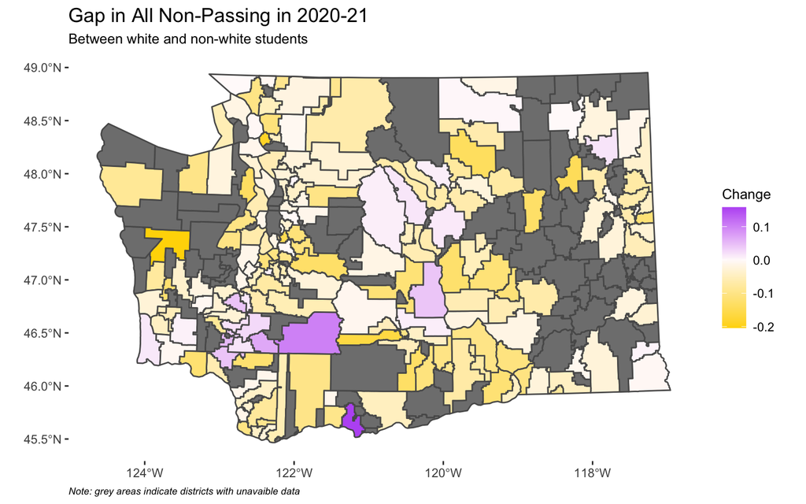

## plot III:

- 9th grade on track: did not get a grade of D or F. The % of students that received grades of A,B, C.
- Regular attendance, meaning that has more than 90% attendance during the year
- Dual credit (not prestigious): (AP/IB courses is more prestigious); therefore, less useful
- COVID-19 modified (beginning of the school year to march, 2019-20 school year). The “modified” may indicate that. then OSPI created a fall to march dataset for multiple years of data

## plot IV; Graduation (the class of 2020).

https://www.k12.wa.us/data-reporting/data-displays/graduation-pathways-display Different pathways by income and students of color